# Ficha de Información Metropolitana

Universidad Autónoma Metropolitnana

Lic. Martínez Rodriguez, Alvaro[^1]

Lic. Pérez Victorino, Leonardo[^2]

La ficha de información metropolitana es una herramienta valiosa para la planificación territorial en zonas metropolitanas (ZM). Proporciona información censal en diferentes formatos, como gráficos, tablas y mapas, tanto de los Censos de Población y Vivienda, 2020 (CPV2020) como de los Censos Económicos de 1999, 2004, 2009, 2014 y 2019. Ambos publicados por el Instituto Nacional de Estadística y Geografía (INEGI).

## Información general de la Zona Metropolitana de Morelia

Según (Sedatu 2018), la zona metropolitana se define como un área urbana que consta de una ciudad principal y su zona conurbada. Las zonas metropolitanas se caracterizan por tener una alta densidad de población y estar interconectadas por vías de transporte y comunicación. La zona metropolitana de Morelia, se localiza en Michoacán de Ocampo. y esta compuesta por 3 municipios, que se muestran a continuación:

| Nombre | Clave |
| --- | --- |
| Charo | 16022 |
| Morelia | 16053 |
| Tarímbaro | 16088 |

Municipios de la zona metropolitana

Además, se presenta un mapa de la zona metropolitana:

[interactive chart not shown]

A continuación se presentan algunos datos generales sobre esta zona:

- Zona Metropolitana:Morelia
- Número de municipios: 3
- Población total: 988,704
- Superficie de la ZM: 1,759.76 [m^2]
- Densidad poblacional: 561.84 [1/m^2] Hab/Km^2.
- Grado promedio de escolaridad: 9.2766667

## Información sociodemográfica

La estructura de población de la zona metropolitana de Morelia se presenta en la una piramide poblacional ya que permite obtener una visión general de la distribución de la población por género y edad:

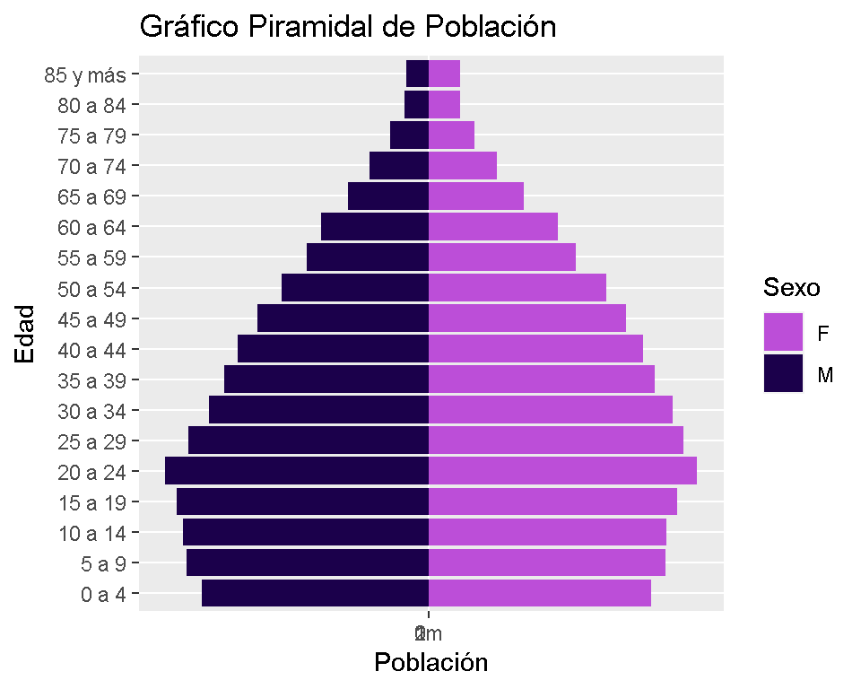

En el siguiente mapa se observa como se distribuye la población sobre la región:

[interactive chart not shown]

### Socioeconómicos

La población en terminos de la poblacioón economicamente activa esta descrita por:

- Porcentaje de población de 12 años y más económicamente activa: 52%
- Porcentaje de población de 12 años y más no económicamente activa: 29% `

### Educación

La educación de la zona metropolitana esta caracterizada por los siguientes estadísticos:

- Porcentaje de población de 15 años y más sin escolaridad:3%
- Porcentaje de población de 15 años y más con al menos un grado aprobado en primaria: 71%
- Porcentaje de población de 15 años y más con educación básica completa: 15%
- Porcentaje de población de 15 años y más con secundaria o equivalente incompleta:3%
- Porcentaje de población de 18 años y más con al menos un grado aprobado en educación media superior: 39%

### Salud

La situación de la afiliación a algún servico de salud es la siguiente:

- Porcentaje de población afiliada a servicios de salud: 67%
- Población sin afiliación a servicios de salud:325482

### Indicadores de desarrollo

Finalmente se presentan tres indicadores de desarrollo; los índices son: índice de Desarrollo Humano (IDH), Índice de Marginación (IM) e Índice de Rezago Social (IRS).

IDH es un indicador elaborado por el Programa de Naciones Unidas para el Desarrollo (PNUD), este busca medir la calidad de vida, así como el progreso socioeconómico de cada entidad y municipio; El cálculo del Índice de Desarrollo Humano se realiza a partir de las tres variables: esperanza de vida, educación e ingreso per cápita.

- Muy Alto - IDH mayor de 1.
- Alto - IDH entre 0.80 a 1.
- Medio - IDH entre 0.50 y 0.80.
- Bajo - IDH entre 0 y 0.50
- Muy Bajo - IDH menores a 0.
- El promedio del IDH en 2020 para la zona metropolitana es de 0.738 según datos del PNUD.

El IM es un índice construido por el consejo Nacional de Población (CONAPO). Este índice considera 4 dimensiones estructurales para su construcción: vivienda, ingreso, educación y distribución de la población. El indice se puede ubicar en 5 estratos designados por la ténica de estratificación de Dalenius-Hodges..

Por último, el IRS es construido por el Consejo Nacional de Evaluación de la Política de Desarrollo Social, CONEVAL, este índice incorpora indicadores de educación, de acceso a servicios de salud, de servicios básicos y tiene como finalidad ordenar los municipios según sus carencias sociales. Este índice, al igual que el IM, se clasifica en cinco estratos.

## Datos económicos.

Con base en la información de los subsectores de los 21 sectores principales de la clasificación del SCIAN, extraída de los Censos Económicos del INEGI durante el periodo de 1998-2018, se ha llevado a cabo la agrupación de los datos de cada municipio que pertenece a una zona metropolitana en cinco grandes sectores: Primarios, Construcción, Manufactura, Comercio y Servicios. Esta clasificación se basa en la metodología proporcionada por el INEGI. Se utilizaron las siguientes variables:

- Unidades económicas (UE) [número de unidades]
- Activiso fijos totales (AF) [miles de pesos a precios corrientes]
- Formación bruta de capital fijo (FB) [miles de pesos a precios corrientes]
- Producción bruta total (PB) [miles de pesos a precios corrientes]
- Personal ocupado total (PO) [número de personas]
- Total de remuneraciones (RE) [miles de pesos a precios corrientes]
- Valor agregado censal bruto (VA) [miles de pesos a precios corrientes]

Posteriormente, se replica la metodología utilizada por García y Carranco (2008) para estimar los coeficientes de participación relativa (PR), de localización de la actividad económica (QL), Hirschman-Herfindahl (HH) e Inverso de Hirschman-Herfindahl (IHH).

$PR_ij$=$X_ij/X_in$

$QL_ij$=$(X_ij⁄X_j )/(X_in⁄X_n)$

$HH_ij$=$X_ij/X_in - X_j/X_n$

$IHH_ij$=$1/(X_ij/X_in - X_j/X_n)$

Donde:

- $X_ij$= Variable económica del sector i en el municipio j
- $X_j$= Variable económica del total de los sectores en el municipio j
- $X_in$= Variable económica del sector i de la Zona Metropolitana del municipio j
- $X_n$= Variable económica del total de los sectores de la Zona Metropolitana del municipio j

### Cifras brutas

#### 1999

##### UE

| Clave | Municipio | Primarios | Construcción | Manufactura | Comercio | Servicios |
| --- | --- | --- | --- | --- | --- | --- |
| 16022 | Charo | 0 | 0 | 0 | 49 | 0 |
| 16053 | Morelia | 0 | 202 | 2,921 | 12,551 | 9,363 |
| 16088 | Tarímbaro | 0 | 0 | 38 | 261 | 64 |

##### AF

| Clave | Municipio | Primarios | Construcción | Manufactura | Comercio | Servicios |
| --- | --- | --- | --- | --- | --- | --- |
| 16022 | Charo | 0 | 0 | 6,147 | 2,730 | 8,157 |
| 16053 | Morelia | 12,635 | 203,037 | 2,657,753 | 1,578,799 | 14,852,632 |
| 16088 | Tarímbaro | 740 | 12,000 | 85,241 | 19,130 | 45,950 |

##### FB

| Clave | Municipio | Primarios | Construcción | Manufactura | Comercio | Servicios |
| --- | --- | --- | --- | --- | --- | --- |
| 16022 | Charo | 0 | 0 | 280 | 60 | -2 |
| 16053 | Morelia | 683 | 21,412 | 234,947 | 65,825 | 489,893 |
| 16088 | Tarímbaro | 0 | 3,100 | 4,114 | 61 | 7,308 |

##### PB

| Clave | Municipio | Primarios | Construcción | Manufactura | Comercio | Servicios |
| --- | --- | --- | --- | --- | --- | --- |
| 16022 | Charo | 0 | 0 | 3,644 | 3,290 | 6,038 |
| 16053 | Morelia | 8,928 | 696,474 | 4,646,810 | 3,846,545 | 14,142,961 |
| 16088 | Tarímbaro | 501 | 40,536 | 109,526 | 17,649 | 15,375 |

##### PO

| Clave | Municipio | Primarios | Construcción | Manufactura | Comercio | Servicios |
| --- | --- | --- | --- | --- | --- | --- |
| 16022 | Charo | 0 | 0 | 36 | 121 | 59 |
| 16053 | Morelia | 98 | 8,131 | 15,089 | 33,855 | 41,320 |
| 16088 | Tarímbaro | 3 | 93 | 692 | 500 | 307 |

##### RE

| Clave | Municipio | Primarios | Construcción | Manufactura | Comercio | Servicios |
| --- | --- | --- | --- | --- | --- | --- |
| 16022 | Charo | 0 | 0 | 346 | 174 | 247 |
| 16053 | Morelia | 1,276 | 77,333 | 373,828 | 558,933 | 1,362,233 |
| 16088 | Tarímbaro | 80 | 3,641 | 20,331 | 1,541 | 6,261 |

##### VA

| Clave | Municipio | Primarios | Construcción | Manufactura | Comercio | Servicios |
| --- | --- | --- | --- | --- | --- | --- |
| 16022 | Charo | 0 | 0 | 2,141 | 2,806 | 2,596 |
| 16053 | Morelia | 3,895 | 140,964 | 955,929 | 2,804,503 | 11,023,558 |
| 16088 | Tarímbaro | 127 | 16,105 | 54,209 | 13,490 | 9,779 |

#### 2004

##### UE

| Clave | Municipio | Primarios | Construcción | Manufactura | Comercio | Servicios |
| --- | --- | --- | --- | --- | --- | --- |
| 16022 | Charo | 0 | 0 | 0 | 96 | 15 |
| 16053 | Morelia | 16 | 276 | 3,111 | 14,589 | 10,321 |
| 16088 | Tarímbaro | 0 | 0 | 25 | 253 | 117 |

##### AF

| Clave | Municipio | Primarios | Construcción | Manufactura | Comercio | Servicios |
| --- | --- | --- | --- | --- | --- | --- |
| 16022 | Charo | 3,892 | 0 | 2,794 | 2,164 | 3,483 |
| 16053 | Morelia | 42,556 | 455,783 | 4,101,911 | 3,180,159 | 23,861,116 |
| 16088 | Tarímbaro | 17,326 | 36,647 | 57,511 | 20,916 | 41,154 |

##### FB

| Clave | Municipio | Primarios | Construcción | Manufactura | Comercio | Servicios |
| --- | --- | --- | --- | --- | --- | --- |
| 16022 | Charo | 0 | 0 | 0 | 0 | 56 |
| 16053 | Morelia | 2,957 | 37,614 | 208,974 | 290,334 | 2,230,488 |
| 16088 | Tarímbaro | 4,586 | 1,500 | 42 | 1,058 | 1,769 |

##### PB

| Clave | Municipio | Primarios | Construcción | Manufactura | Comercio | Servicios |
| --- | --- | --- | --- | --- | --- | --- |
| 16022 | Charo | 2,160 | 0 | 8,537 | 5,246 | 4,532 |
| 16053 | Morelia | 18,228 | 2,271,438 | 9,997,676 | 7,297,523 | 24,310,698 |
| 16088 | Tarímbaro | 7,617 | 78,367 | 149,269 | 75,836 | 62,167 |

##### PO

| Clave | Municipio | Primarios | Construcción | Manufactura | Comercio | Servicios |
| --- | --- | --- | --- | --- | --- | --- |
| 16022 | Charo | 12 | 0 | 39 | 176 | 71 |
| 16053 | Morelia | 102 | 10,624 | 14,985 | 45,851 | 56,071 |
| 16088 | Tarímbaro | 31 | 737 | 813 | 726 | 656 |

##### RE

| Clave | Municipio | Primarios | Construcción | Manufactura | Comercio | Servicios |
| --- | --- | --- | --- | --- | --- | --- |
| 16022 | Charo | 498 | 0 | 832 | 529 | 544 |
| 16053 | Morelia | 2,756 | 236,973 | 552,720 | 1,104,367 | 2,937,980 |
| 16088 | Tarímbaro | 1,189 | 16,735 | 35,406 | 19,723 | 17,438 |

##### VA

| Clave | Municipio | Primarios | Construcción | Manufactura | Comercio | Servicios |
| --- | --- | --- | --- | --- | --- | --- |
| 16022 | Charo | 1,195 | 0 | 3,804 | 4,114 | 1,927 |
| 16053 | Morelia | 9,355 | 817,216 | 3,539,388 | 5,305,662 | 19,450,774 |
| 16088 | Tarímbaro | 2,926 | 10,371 | 60,704 | 54,939 | 38,509 |

#### 2009

##### UE

| Clave | Municipio | Primarios | Construcción | Manufactura | Comercio | Servicios |
| --- | --- | --- | --- | --- | --- | --- |
| 16022 | Charo | 0 | 0 | 39 | 172 | 53 |
| 16053 | Morelia | 16 | 293 | 3,916 | 16,242 | 14,817 |
| 16088 | Tarímbaro | 0 | 0 | 57 | 438 | 187 |

##### AF

| Clave | Municipio | Primarios | Construcción | Manufactura | Comercio | Servicios |
| --- | --- | --- | --- | --- | --- | --- |
| 16022 | Charo | 2,560 | 0 | 1,817 | 4,733 | 10,356 |
| 16053 | Morelia | 53,930 | 882,870 | 4,911,450 | 5,286,446 | 56,461,873 |
| 16088 | Tarímbaro | 13,717 | 19,912 | 93,675 | 354,225 | 100,967 |

##### FB

| Clave | Municipio | Primarios | Construcción | Manufactura | Comercio | Servicios |
| --- | --- | --- | --- | --- | --- | --- |
| 16022 | Charo | 0 | 0 | 462 | 681 | 663 |
| 16053 | Morelia | 2,565 | 39,894 | 316,825 | 289,779 | 1,743,574 |
| 16088 | Tarímbaro | 0 | 263 | 12,793 | 27,697 | 1,068 |

##### PB

| Clave | Municipio | Primarios | Construcción | Manufactura | Comercio | Servicios |
| --- | --- | --- | --- | --- | --- | --- |
| 16022 | Charo | 4,025 | 0 | 9,785 | 8,299 | 9,170 |
| 16053 | Morelia | 27,361 | 4,470,667 | 12,920,440 | 8,904,725 | 25,029,985 |
| 16088 | Tarímbaro | 20,687 | 129,874 | 171,042 | 574,875 | 60,784 |

##### PO

| Clave | Municipio | Primarios | Construcción | Manufactura | Comercio | Servicios |
| --- | --- | --- | --- | --- | --- | --- |
| 16022 | Charo | 13 | 0 | 197 | 364 | 231 |
| 16053 | Morelia | 130 | 10,057 | 20,694 | 56,841 | 72,607 |
| 16088 | Tarímbaro | 32 | 136 | 518 | 2,132 | 974 |

##### RE

| Clave | Municipio | Primarios | Construcción | Manufactura | Comercio | Servicios |
| --- | --- | --- | --- | --- | --- | --- |
| 16022 | Charo | 639 | 0 | 1,155 | 608 | 1,030 |
| 16053 | Morelia | 4,524 | 382,918 | 1,207,926 | 1,518,031 | 4,256,245 |
| 16088 | Tarímbaro | 1,859 | 5,878 | 23,010 | 82,931 | 27,918 |

##### VA

| Clave | Municipio | Primarios | Construcción | Manufactura | Comercio | Servicios |
| --- | --- | --- | --- | --- | --- | --- |
| 16022 | Charo | 1,806 | 0 | 4,060 | 5,469 | 2,471 |
| 16053 | Morelia | 16,180 | 1,259,207 | 3,173,712 | 5,318,604 | 10,929,531 |
| 16088 | Tarímbaro | 10,111 | 16,914 | 23,684 | 309,480 | 27,080 |

#### 2014

##### UE

| Clave | Municipio | Primarios | Construcción | Manufactura | Comercio | Servicios |
| --- | --- | --- | --- | --- | --- | --- |
| 16022 | Charo | 0 | 0 | 36 | 170 | 49 |
| 16053 | Morelia | 36 | 247 | 4,135 | 16,396 | 16,366 |
| 16088 | Tarímbaro | 0 | 0 | 98 | 661 | 367 |

##### AF

| Clave | Municipio | Primarios | Construcción | Manufactura | Comercio | Servicios |
| --- | --- | --- | --- | --- | --- | --- |
| 16022 | Charo | 0 | 0 | 1,630 | 5,479 | 3,211 |
| 16053 | Morelia | 45,781 | 729,954 | 9,651,391 | 7,056,804 | 8,660,303 |
| 16088 | Tarímbaro | 0 | 0 | 28,239 | 3,278,985 | 24,035 |

##### FB

| Clave | Municipio | Primarios | Construcción | Manufactura | Comercio | Servicios |
| --- | --- | --- | --- | --- | --- | --- |
| 16022 | Charo | 0 | 0 | 2 | 41 | 35 |
| 16053 | Morelia | 300 | 38,587 | 635,642 | 398,976 | 428,977 |
| 16088 | Tarímbaro | 0 | 0 | 2,111 | 582,539 | 223 |

##### PB

| Clave | Municipio | Primarios | Construcción | Manufactura | Comercio | Servicios |
| --- | --- | --- | --- | --- | --- | --- |
| 16022 | Charo | 0 | 0 | 8,551 | 6,237 | 2,932 |
| 16053 | Morelia | 20,324 | 2,712,374 | 13,972,895 | 13,215,020 | 17,750,870 |
| 16088 | Tarímbaro | 0 | 0 | 78,341 | 601,398 | 69,180 |

##### PO

| Clave | Municipio | Primarios | Construcción | Manufactura | Comercio | Servicios |
| --- | --- | --- | --- | --- | --- | --- |
| 16022 | Charo | 0 | 0 | 87 | 248 | 65 |
| 16053 | Morelia | 199 | 7,841 | 17,834 | 55,640 | 72,175 |
| 16088 | Tarímbaro | 0 | 0 | 377 | 1,978 | 821 |

##### RE

| Clave | Municipio | Primarios | Construcción | Manufactura | Comercio | Servicios |
| --- | --- | --- | --- | --- | --- | --- |
| 16022 | Charo | 0 | 0 | 494 | 701 | 347 |
| 16053 | Morelia | 4,699 | 439,891 | 1,001,941 | 1,596,690 | 3,902,576 |
| 16088 | Tarímbaro | 0 | 0 | 14,156 | 149,940 | 9,363 |

##### VA

| Clave | Municipio | Primarios | Construcción | Manufactura | Comercio | Servicios |
| --- | --- | --- | --- | --- | --- | --- |
| 16022 | Charo | 0 | 0 | 3,786 | 3,788 | 1,290 |
| 16053 | Morelia | 10,740 | 928,946 | 3,076,250 | 8,262,908 | 10,481,579 |
| 16088 | Tarímbaro | 0 | 0 | 33,444 | 362,224 | 29,379 |

#### 2019

##### UE

| Clave | Municipio | Primarios | Construcción | Manufactura | Comercio | Servicios |
| --- | --- | --- | --- | --- | --- | --- |
| 16022 | Charo | 2 | 1 | 46 | 189 | 102 |
| 16053 | Morelia | 34 | 238 | 4,618 | 17,637 | 18,728 |
| 16088 | Tarímbaro | 8 | 4 | 179 | 840 | 542 |

##### AF

| Clave | Municipio | Primarios | Construcción | Manufactura | Comercio | Servicios |
| --- | --- | --- | --- | --- | --- | --- |
| 16022 | Charo | 0 | 0 | 21,770 | 64,753 | 9,852 |
| 16053 | Morelia | 7,868 | 1,144,213 | 10,927,067 | 11,073,151 | 13,320,805 |
| 16088 | Tarímbaro | 1,748 | 0 | 208,299 | 855,607 | 182,381 |

##### FB

| Clave | Municipio | Primarios | Construcción | Manufactura | Comercio | Servicios |
| --- | --- | --- | --- | --- | --- | --- |
| 16022 | Charo | 0 | 0 | 1,424 | 658 | 0 |
| 16053 | Morelia | 30 | 85,620 | 397,780 | 594,604 | 391,473 |
| 16088 | Tarímbaro | 2 | 0 | 14,914 | 17,340 | 1,601 |

##### PB

| Clave | Municipio | Primarios | Construcción | Manufactura | Comercio | Servicios |
| --- | --- | --- | --- | --- | --- | --- |
| 16022 | Charo | 0 | 0 | 75,355 | 23,909 | 8,748 |
| 16053 | Morelia | 1,996 | 5,377,324 | 32,112,998 | 23,752,792 | 34,122,683 |
| 16088 | Tarímbaro | 1,716 | 0 | 651,142 | 3,516,388 | 290,264 |

##### PO

| Clave | Municipio | Primarios | Construcción | Manufactura | Comercio | Servicios |
| --- | --- | --- | --- | --- | --- | --- |
| 16022 | Charo | 0 | 0 | 159 | 335 | 112 |
| 16053 | Morelia | 58 | 9,387 | 23,226 | 63,024 | 103,691 |
| 16088 | Tarímbaro | 38 | 0 | 991 | 2,932 | 1,609 |

##### RE

| Clave | Municipio | Primarios | Construcción | Manufactura | Comercio | Servicios |
| --- | --- | --- | --- | --- | --- | --- |
| 16022 | Charo | 0 | 0 | 14,682 | 3,538 | 2,102 |
| 16053 | Morelia | 480 | 564,226 | 1,700,607 | 2,551,330 | 6,026,531 |
| 16088 | Tarímbaro | 649 | 0 | 75,956 | 242,154 | 86,953 |

##### VA

| Clave | Municipio | Primarios | Construcción | Manufactura | Comercio | Servicios |
| --- | --- | --- | --- | --- | --- | --- |
| 16022 | Charo | 0 | 0 | 6,305 | 18,236 | 4,150 |
| 16053 | Morelia | 731 | 1,991,390 | 11,245,069 | 17,287,059 | 21,071,736 |
| 16088 | Tarímbaro | 806 | 0 | 149,973 | 2,292,170 | 180,375 |

### Coeficientes de localización (QL)

#### 1999

##### UE

| Clave | Municipio | Primarios | Construcción | Manufactura | Comercio | Servicios |
| --- | --- | --- | --- | --- | --- | --- |
| 16022 | Charo | 0.0000 | 0.0000 | 0.0000 | 1.8953 | 0.0000 |
| 16053 | Morelia | 0.0000 | 1.3567 | 1.0515 | 0.9501 | 1.0599 |
| 16088 | Tarímbaro | 0.0000 | 0.0000 | 0.9435 | 1.3627 | 0.4997 |

##### AF

| Clave | Municipio | Primarios | Construcción | Manufactura | Comercio | Servicios |
| --- | --- | --- | --- | --- | --- | --- |
| 16022 | Charo | 0.0000 | 0.0000 | 1.0606 | 2.1102 | 0.8799 |
| 16053 | Morelia | 0.0269 | 0.6908 | 0.4046 | 1.0768 | 1.4137 |
| 16088 | Tarímbaro | 0.1865 | 4.8334 | 1.5364 | 1.5447 | 0.5178 |

##### FB

[output not shown]

##### PB

| Clave | Municipio | Primarios | Construcción | Manufactura | Comercio | Servicios |
| --- | --- | --- | --- | --- | --- | --- |
| 16022 | Charo | 0.0000 | 0.0000 | 0.5677 | 1.8150 | 1.4574 |
| 16053 | Morelia | 0.0383 | 0.8269 | 0.4023 | 1.1793 | 1.8971 |
| 16088 | Tarímbaro | 0.2735 | 6.1191 | 1.2057 | 0.6880 | 0.2622 |

##### PO

| Clave | Municipio | Primarios | Construcción | Manufactura | Comercio | Servicios |
| --- | --- | --- | --- | --- | --- | --- |
| 16022 | Charo | 0.0000 | 0.0000 | 0.5399 | 2.1590 | 0.7397 |
| 16053 | Morelia | 0.1122 | 1.5373 | 0.4963 | 1.3247 | 1.1361 |
| 16088 | Tarímbaro | 0.2120 | 1.0858 | 1.4055 | 1.2082 | 0.5212 |

##### RE

| Clave | Municipio | Primarios | Construcción | Manufactura | Comercio | Servicios |
| --- | --- | --- | --- | --- | --- | --- |
| 16022 | Charo | 0.0000 | 0.0000 | 1.2201 | 1.5976 | 0.7137 |
| 16053 | Morelia | 0.0474 | 1.2678 | 0.4260 | 1.6583 | 1.2719 |
| 16088 | Tarímbaro | 0.2215 | 4.4478 | 1.7262 | 0.3407 | 0.4356 |

##### VA

| Clave | Municipio | Primarios | Construcción | Manufactura | Comercio | Servicios |
| --- | --- | --- | --- | --- | --- | --- |
| 16022 | Charo | 0.0000 | 0.0000 | 0.7704 | 1.6701 | 0.9182 |
| 16053 | Morelia | 0.0222 | 0.4247 | 0.1738 | 0.8434 | 1.9700 |
| 16088 | Tarímbaro | 0.1153 | 7.7303 | 1.5700 | 0.6463 | 0.2784 |

#### 2004

##### UE

| Clave | Municipio | Primarios | Construcción | Manufactura | Comercio | Servicios |
| --- | --- | --- | --- | --- | --- | --- |
| 16022 | Charo | 0.0000 | 0.0000 | 0.0000 | 1.6018 | 0.3801 |
| 16053 | Morelia | 0.3138 | 1.9699 | 1.1241 | 0.9543 | 1.0252 |
| 16088 | Tarímbaro | 0.0000 | 0.0000 | 0.6475 | 1.1863 | 0.8330 |

##### AF

| Clave | Municipio | Primarios | Construcción | Manufactura | Comercio | Servicios |
| --- | --- | --- | --- | --- | --- | --- |
| 16022 | Charo | 18.9752 | 0.0000 | 0.6184 | 1.9510 | 0.5472 |
| 16053 | Morelia | 0.0809 | 1.3111 | 0.3539 | 1.1175 | 1.4612 |
| 16088 | Tarímbaro | 6.0027 | 19.2192 | 0.9045 | 1.3400 | 0.4595 |

##### FB

[output not shown]

##### PB

| Clave | Municipio | Primarios | Construcción | Manufactura | Comercio | Servicios |
| --- | --- | --- | --- | --- | --- | --- |
| 16022 | Charo | 10.3237 | 0.0000 | 0.9027 | 1.8653 | 0.6168 |
| 16053 | Morelia | 0.0406 | 1.6348 | 0.4931 | 1.2103 | 1.5432 |
| 16088 | Tarímbaro | 1.9970 | 6.6332 | 0.8658 | 1.4792 | 0.4641 |

##### PO

| Clave | Municipio | Primarios | Construcción | Manufactura | Comercio | Servicios |
| --- | --- | --- | --- | --- | --- | --- |
| 16022 | Charo | 4.8718 | 0.0000 | 0.4967 | 2.0201 | 0.6115 |
| 16053 | Morelia | 0.0967 | 1.7995 | 0.4456 | 1.2288 | 1.1275 |
| 16088 | Tarímbaro | 1.2658 | 5.3774 | 1.0414 | 0.8381 | 0.5682 |

##### RE

| Clave | Municipio | Primarios | Construcción | Manufactura | Comercio | Servicios |
| --- | --- | --- | --- | --- | --- | --- |
| 16022 | Charo | 21.7691 | 0.0000 | 0.9872 | 1.4081 | 0.4950 |
| 16053 | Morelia | 0.0599 | 1.8770 | 0.3260 | 1.4611 | 1.3288 |
| 16088 | Tarímbaro | 1.3802 | 7.0822 | 1.1156 | 1.3941 | 0.4214 |

##### VA

| Clave | Municipio | Primarios | Construcción | Manufactura | Comercio | Servicios |
| --- | --- | --- | --- | --- | --- | --- |
| 16022 | Charo | 6.7181 | 0.0000 | 1.0601 | 1.8916 | 0.3971 |
| 16053 | Morelia | 0.0199 | 1.2558 | 0.3739 | 0.9248 | 1.5196 |
| 16088 | Tarímbaro | 1.0845 | 2.7716 | 1.1153 | 1.6654 | 0.5233 |

#### 2009

##### UE

| Clave | Municipio | Primarios | Construcción | Manufactura | Comercio | Servicios |
| --- | --- | --- | --- | --- | --- | --- |
| 16022 | Charo | 0.0000 | 0.0000 | 1.4343 | 1.2813 | 0.5268 |
| 16053 | Morelia | 0.3100 | 1.3953 | 1.0775 | 0.9053 | 1.1019 |
| 16088 | Tarímbaro | 0.0000 | 0.0000 | 0.8114 | 1.2631 | 0.7194 |

##### AF

| Clave | Municipio | Primarios | Construcción | Manufactura | Comercio | Servicios |
| --- | --- | --- | --- | --- | --- | --- |
| 16022 | Charo | 6.9383 | 0.0000 | 0.3490 | 2.5856 | 0.8813 |
| 16053 | Morelia | 0.0421 | 0.8225 | 0.2717 | 0.8317 | 1.3837 |
| 16088 | Tarímbaro | 1.2424 | 2.1527 | 0.6013 | 6.4668 | 0.2871 |

##### FB

[output not shown]

##### PB

| Clave | Municipio | Primarios | Construcción | Manufactura | Comercio | Servicios |
| --- | --- | --- | --- | --- | --- | --- |
| 16022 | Charo | 7.1054 | 0.0000 | 0.6446 | 2.5360 | 0.8384 |
| 16053 | Morelia | 0.0294 | 2.0593 | 0.5184 | 1.6574 | 1.3938 |
| 16088 | Tarímbaro | 1.1933 | 3.2093 | 0.3682 | 5.7401 | 0.1816 |

##### PO

| Clave | Municipio | Primarios | Construcción | Manufactura | Comercio | Servicios |
| --- | --- | --- | --- | --- | --- | --- |
| 16022 | Charo | 2.2621 | 0.0000 | 1.0293 | 1.5903 | 0.6657 |
| 16053 | Morelia | 0.1136 | 1.5783 | 0.5429 | 1.2469 | 1.0506 |
| 16088 | Tarímbaro | 1.1821 | 0.9024 | 0.5746 | 1.9774 | 0.5959 |

##### RE

| Clave | Municipio | Primarios | Construcción | Manufactura | Comercio | Servicios |
| --- | --- | --- | --- | --- | --- | --- |
| 16022 | Charo | 13.7409 | 0.0000 | 1.0208 | 1.3898 | 0.6102 |
| 16053 | Morelia | 0.0453 | 1.3875 | 0.4972 | 1.6159 | 1.1742 |
| 16088 | Tarímbaro | 0.9689 | 1.1085 | 0.4929 | 4.5946 | 0.4009 |

##### VA

| Clave | Municipio | Primarios | Construcción | Manufactura | Comercio | Servicios |
| --- | --- | --- | --- | --- | --- | --- |
| 16022 | Charo | 4.6104 | 0.0000 | 0.8297 | 2.7464 | 0.4037 |
| 16053 | Morelia | 0.0276 | 2.0553 | 0.4326 | 1.7816 | 1.1910 |
| 16088 | Tarímbaro | 0.9202 | 1.4754 | 0.1726 | 5.5404 | 0.1577 |

#### 2014

##### UE

| Clave | Municipio | Primarios | Construcción | Manufactura | Comercio | Servicios |
| --- | --- | --- | --- | --- | --- | --- |
| 16022 | Charo | 0.0000 | 0.0000 | 1.4375 | 1.3658 | 0.4721 |
| 16053 | Morelia | 0.5730 | 1.3312 | 1.1324 | 0.9034 | 1.0816 |
| 16088 | Tarímbaro | 0.0000 | 0.0000 | 0.8862 | 1.2026 | 0.8008 |

##### AF

| Clave | Municipio | Primarios | Construcción | Manufactura | Comercio | Servicios |
| --- | --- | --- | --- | --- | --- | --- |
| 16022 | Charo | 0.0000 | 0.0000 | 0.5777 | 4.8298 | 0.5269 |
| 16053 | Morelia | 0.1336 | 2.1345 | 1.3501 | 2.4555 | 0.5610 |
| 16088 | Tarímbaro | 0.0000 | 0.0000 | 0.0310 | 8.9544 | 0.0122 |

##### FB

[output not shown]

##### PB

| Clave | Municipio | Primarios | Construcción | Manufactura | Comercio | Servicios |
| --- | --- | --- | --- | --- | --- | --- |
| 16022 | Charo | 0.0000 | 0.0000 | 0.9875 | 2.9519 | 0.4646 |
| 16053 | Morelia | 0.0756 | 1.8797 | 0.5998 | 2.3249 | 1.0455 |
| 16088 | Tarímbaro | 0.0000 | 0.0000 | 0.2141 | 6.7347 | 0.2594 |

##### PO

| Clave | Municipio | Primarios | Construcción | Manufactura | Comercio | Servicios |
| --- | --- | --- | --- | --- | --- | --- |
| 16022 | Charo | 0.0000 | 0.0000 | 0.9002 | 2.1740 | 0.3700 |
| 16053 | Morelia | 0.3182 | 1.7068 | 0.4803 | 1.2694 | 1.0692 |
| 16088 | Tarímbaro | 0.0000 | 0.0000 | 0.4913 | 2.1838 | 0.5885 |

##### RE

| Clave | Municipio | Primarios | Construcción | Manufactura | Comercio | Servicios |
| --- | --- | --- | --- | --- | --- | --- |
| 16022 | Charo | 0.0000 | 0.0000 | 0.9384 | 3.3075 | 0.4674 |
| 16053 | Morelia | 0.0416 | 2.7025 | 0.4225 | 1.6725 | 1.1670 |
| 16088 | Tarímbaro | 0.0000 | 0.0000 | 0.2391 | 6.2891 | 0.1121 |

##### VA

| Clave | Municipio | Primarios | Construcción | Manufactura | Comercio | Servicios |
| --- | --- | --- | --- | --- | --- | --- |
| 16022 | Charo | 0.0000 | 0.0000 | 1.2701 | 2.4218 | 0.3181 |
| 16053 | Morelia | 0.0614 | 1.8528 | 0.4019 | 2.0573 | 1.0065 |
| 16088 | Tarímbaro | 0.0000 | 0.0000 | 0.2340 | 4.8294 | 0.1511 |

#### 2019

##### UE

| Clave | Municipio | Primarios | Construcción | Manufactura | Comercio | Servicios |
| --- | --- | --- | --- | --- | --- | --- |
| 16022 | Charo | 2.4758 | 0.5670 | 1.3687 | 1.1852 | 0.7066 |
| 16053 | Morelia | 0.3469 | 1.1121 | 1.1324 | 0.9115 | 1.0692 |
| 16088 | Tarímbaro | 2.1406 | 0.4902 | 1.1512 | 1.1386 | 0.8116 |

##### AF

| Clave | Municipio | Primarios | Construcción | Manufactura | Comercio | Servicios |
| --- | --- | --- | --- | --- | --- | --- |
| 16022 | Charo | 0.0000 | 0.0000 | 0.7974 | 3.4323 | 0.2072 |
| 16053 | Morelia | 0.0139 | 2.5681 | 1.0575 | 1.5509 | 0.7404 |
| 16088 | Tarímbaro | 0.0905 | 0.0000 | 0.5892 | 3.5021 | 0.2963 |

##### FB

[output not shown]

##### PB

| Clave | Municipio | Primarios | Construcción | Manufactura | Comercio | Servicios |
| --- | --- | --- | --- | --- | --- | --- |
| 16022 | Charo | 0.0000 | 0.0000 | 1.3975 | 1.5838 | 0.2468 |
| 16053 | Morelia | 0.0048 | 1.9811 | 0.6745 | 1.7821 | 1.0902 |
| 16088 | Tarímbaro | 0.0879 | 0.0000 | 0.2925 | 5.6419 | 0.1983 |

##### PO

| Clave | Municipio | Primarios | Construcción | Manufactura | Comercio | Servicios |
| --- | --- | --- | --- | --- | --- | --- |
| 16022 | Charo | 0.0000 | 0.0000 | 1.0682 | 2.1397 | 0.3989 |
| 16053 | Morelia | 0.0731 | 1.6395 | 0.4742 | 1.2234 | 1.1225 |
| 16088 | Tarímbaro | 1.7148 | 0.0000 | 0.7243 | 2.0374 | 0.6235 |

##### RE

| Clave | Municipio | Primarios | Construcción | Manufactura | Comercio | Servicios |
| --- | --- | --- | --- | --- | --- | --- |
| 16022 | Charo | 0.0000 | 0.0000 | 1.9983 | 1.2869 | 0.2160 |
| 16053 | Morelia | 0.0131 | 2.4925 | 0.4338 | 1.7392 | 1.1605 |
| 16088 | Tarímbaro | 0.4739 | 0.0000 | 0.5178 | 4.4118 | 0.4475 |

##### VA

| Clave | Municipio | Primarios | Construcción | Manufactura | Comercio | Servicios |
| --- | --- | --- | --- | --- | --- | --- |
| 16022 | Charo | 0.0000 | 0.0000 | 0.6419 | 2.8783 | 0.3528 |
| 16053 | Morelia | 0.0032 | 1.7256 | 0.6366 | 1.5173 | 0.9961 |
| 16088 | Tarímbaro | 0.0688 | 0.0000 | 0.1670 | 3.9569 | 0.1677 |

### Participación Relativa (PR)

#### 1999

##### UE

| Clave | Municipio | Primarios | Construcción | Manufactura | Comercio | Servicios |
| --- | --- | --- | --- | --- | --- | --- |
| 16022 | Charo | 0.0000 | 0.0000 | 0.0000 | 0.0000 | 0.0000 |
| 16053 | Morelia | 0.0000 | 0.0182 | 0.0141 | 0.0128 | 0.0143 |
| 16088 | Tarímbaro | 0.0000 | 0.0000 | 0.0002 | 0.0003 | 0.0001 |

##### AF

| Clave | Municipio | Primarios | Construcción | Manufactura | Comercio | Servicios |
| --- | --- | --- | --- | --- | --- | --- |
| 16022 | Charo | 0e+00 | 0.0000 | 0.0000 | 0.0000 | 0.0000 |
| 16053 | Morelia | 2e-04 | 0.0063 | 0.0037 | 0.0098 | 0.0129 |
| 16088 | Tarímbaro | 0e+00 | 0.0004 | 0.0001 | 0.0001 | 0.0000 |

##### FB

[output not shown]

##### PB

| Clave | Municipio | Primarios | Construcción | Manufactura | Comercio | Servicios |
| --- | --- | --- | --- | --- | --- | --- |
| 16022 | Charo | 0e+00 | 0e+00 | 0.0000 | 0.0000 | 0.0000 |
| 16053 | Morelia | 3e-04 | 6e-03 | 0.0029 | 0.0086 | 0.0138 |
| 16088 | Tarímbaro | 0e+00 | 4e-04 | 0.0001 | 0.0000 | 0.0000 |

##### PO

| Clave | Municipio | Primarios | Construcción | Manufactura | Comercio | Servicios |
| --- | --- | --- | --- | --- | --- | --- |
| 16022 | Charo | 0.0000 | 0.0000 | 0.0000 | 0.0000 | 0e+00 |
| 16053 | Morelia | 0.0010 | 0.0136 | 0.0044 | 0.0117 | 1e-02 |
| 16088 | Tarímbaro | 0.0000 | 0.0002 | 0.0002 | 0.0002 | 1e-04 |

##### RE

| Clave | Municipio | Primarios | Construcción | Manufactura | Comercio | Servicios |
| --- | --- | --- | --- | --- | --- | --- |
| 16022 | Charo | 0e+00 | 0.0000 | 0.0000 | 0.0000 | 0.0000 |
| 16053 | Morelia | 2e-04 | 0.0064 | 0.0021 | 0.0083 | 0.0064 |
| 16088 | Tarímbaro | 0e+00 | 0.0003 | 0.0001 | 0.0000 | 0.0000 |

##### VA

| Clave | Municipio | Primarios | Construcción | Manufactura | Comercio | Servicios |
| --- | --- | --- | --- | --- | --- | --- |
| 16022 | Charo | 0e+00 | 0.0000 | 0.0000 | 0.0000 | 0.0000 |
| 16053 | Morelia | 2e-04 | 0.0047 | 0.0019 | 0.0093 | 0.0216 |
| 16088 | Tarímbaro | 0e+00 | 0.0005 | 0.0001 | 0.0000 | 0.0000 |

#### 2004

##### UE

| Clave | Municipio | Primarios | Construcción | Manufactura | Comercio | Servicios |
| --- | --- | --- | --- | --- | --- | --- |
| 16022 | Charo | 0.0000 | 0.0000 | 0.0000 | 0.0001 | 0.0000 |
| 16053 | Morelia | 0.0045 | 0.0284 | 0.0162 | 0.0138 | 0.0148 |
| 16088 | Tarímbaro | 0.0000 | 0.0000 | 0.0001 | 0.0002 | 0.0002 |

##### AF

| Clave | Municipio | Primarios | Construcción | Manufactura | Comercio | Servicios |
| --- | --- | --- | --- | --- | --- | --- |
| 16022 | Charo | 1e-04 | 0.0000 | 0.0000 | 0.0000 | 0.0000 |
| 16053 | Morelia | 9e-04 | 0.0144 | 0.0039 | 0.0123 | 0.0161 |
| 16088 | Tarímbaro | 4e-04 | 0.0012 | 0.0001 | 0.0001 | 0.0000 |

##### FB

[output not shown]

##### PB

| Clave | Municipio | Primarios | Construcción | Manufactura | Comercio | Servicios |
| --- | --- | --- | --- | --- | --- | --- |
| 16022 | Charo | 0e+00 | 0.0000 | 0.0000 | 0.0000 | 0.0000 |
| 16053 | Morelia | 3e-04 | 0.0140 | 0.0042 | 0.0104 | 0.0132 |
| 16088 | Tarímbaro | 1e-04 | 0.0005 | 0.0001 | 0.0001 | 0.0000 |

##### PO

| Clave | Municipio | Primarios | Construcción | Manufactura | Comercio | Servicios |
| --- | --- | --- | --- | --- | --- | --- |
| 16022 | Charo | 1e-04 | 0.0000 | 0.0000 | 0.0000 | 0.0000 |
| 16053 | Morelia | 1e-03 | 0.0178 | 0.0044 | 0.0122 | 0.0112 |
| 16088 | Tarímbaro | 3e-04 | 0.0012 | 0.0002 | 0.0002 | 0.0001 |

##### RE

| Clave | Municipio | Primarios | Construcción | Manufactura | Comercio | Servicios |
| --- | --- | --- | --- | --- | --- | --- |
| 16022 | Charo | 1e-04 | 0.0000 | 0.0000 | 0.0000 | 0.0000 |
| 16053 | Morelia | 4e-04 | 0.0124 | 0.0022 | 0.0097 | 0.0088 |
| 16088 | Tarímbaro | 2e-04 | 0.0009 | 0.0001 | 0.0002 | 0.0001 |

##### VA

| Clave | Municipio | Primarios | Construcción | Manufactura | Comercio | Servicios |
| --- | --- | --- | --- | --- | --- | --- |
| 16022 | Charo | 0e+00 | 0.0000 | 0.0000 | 0.0000 | 0.0000 |
| 16053 | Morelia | 2e-04 | 0.0149 | 0.0044 | 0.0110 | 0.0180 |
| 16088 | Tarímbaro | 1e-04 | 0.0002 | 0.0001 | 0.0001 | 0.0000 |

#### 2009

##### UE

| Clave | Municipio | Primarios | Construcción | Manufactura | Comercio | Servicios |
| --- | --- | --- | --- | --- | --- | --- |
| 16022 | Charo | 0.0000 | 0.0000 | 0.0002 | 0.0001 | 0.0001 |
| 16053 | Morelia | 0.0045 | 0.0205 | 0.0158 | 0.0133 | 0.0162 |
| 16088 | Tarímbaro | 0.0000 | 0.0000 | 0.0002 | 0.0004 | 0.0002 |

##### AF

| Clave | Municipio | Primarios | Construcción | Manufactura | Comercio | Servicios |
| --- | --- | --- | --- | --- | --- | --- |
| 16022 | Charo | 0e+00 | 0.0000 | 0.0000 | 0.0000 | 0.0000 |
| 16053 | Morelia | 6e-04 | 0.0117 | 0.0039 | 0.0118 | 0.0197 |
| 16088 | Tarímbaro | 2e-04 | 0.0003 | 0.0001 | 0.0008 | 0.0000 |

##### FB

[output not shown]

##### PB

| Clave | Municipio | Primarios | Construcción | Manufactura | Comercio | Servicios |
| --- | --- | --- | --- | --- | --- | --- |
| 16022 | Charo | 0e+00 | 0.0000 | 0.0000 | 0.0000 | 0.0000 |
| 16053 | Morelia | 2e-04 | 0.0123 | 0.0031 | 0.0099 | 0.0083 |
| 16088 | Tarímbaro | 1e-04 | 0.0004 | 0.0000 | 0.0006 | 0.0000 |

##### PO

| Clave | Municipio | Primarios | Construcción | Manufactura | Comercio | Servicios |
| --- | --- | --- | --- | --- | --- | --- |
| 16022 | Charo | 0.0001 | 0.0000 | 0.0001 | 0.0001 | 0.0000 |
| 16053 | Morelia | 0.0011 | 0.0160 | 0.0055 | 0.0126 | 0.0106 |
| 16088 | Tarímbaro | 0.0003 | 0.0002 | 0.0001 | 0.0005 | 0.0001 |

##### RE

| Clave | Municipio | Primarios | Construcción | Manufactura | Comercio | Servicios |
| --- | --- | --- | --- | --- | --- | --- |
| 16022 | Charo | 0e+00 | 0.0000 | 0.0000 | 0.0000 | 0.0000 |
| 16053 | Morelia | 3e-04 | 0.0103 | 0.0037 | 0.0120 | 0.0087 |
| 16088 | Tarímbaro | 1e-04 | 0.0002 | 0.0001 | 0.0007 | 0.0001 |

##### VA

| Clave | Municipio | Primarios | Construcción | Manufactura | Comercio | Servicios |
| --- | --- | --- | --- | --- | --- | --- |
| 16022 | Charo | 0e+00 | 0.0000 | 0.0000 | 0.0000 | 0.0000 |
| 16053 | Morelia | 2e-04 | 0.0118 | 0.0025 | 0.0102 | 0.0068 |
| 16088 | Tarímbaro | 1e-04 | 0.0002 | 0.0000 | 0.0006 | 0.0000 |

#### 2014

##### UE

| Clave | Municipio | Primarios | Construcción | Manufactura | Comercio | Servicios |
| --- | --- | --- | --- | --- | --- | --- |
| 16022 | Charo | 0.0000 | 0.0000 | 0.0001 | 0.0001 | 0.0000 |
| 16053 | Morelia | 0.0077 | 0.0180 | 0.0153 | 0.0122 | 0.0146 |
| 16088 | Tarímbaro | 0.0000 | 0.0000 | 0.0004 | 0.0005 | 0.0003 |

##### AF

| Clave | Municipio | Primarios | Construcción | Manufactura | Comercio | Servicios |
| --- | --- | --- | --- | --- | --- | --- |
| 16022 | Charo | 0e+00 | 0.0000 | 0.0000 | 0.0000 | 0.0000 |
| 16053 | Morelia | 6e-04 | 0.0100 | 0.0063 | 0.0115 | 0.0026 |
| 16088 | Tarímbaro | 0e+00 | 0.0000 | 0.0000 | 0.0054 | 0.0000 |

##### FB

[output not shown]

##### PB

| Clave | Municipio | Primarios | Construcción | Manufactura | Comercio | Servicios |
| --- | --- | --- | --- | --- | --- | --- |
| 16022 | Charo | 0e+00 | 0.0000 | 0.0000 | 0.0000 | 0.0000 |
| 16053 | Morelia | 4e-04 | 0.0090 | 0.0029 | 0.0111 | 0.0050 |
| 16088 | Tarímbaro | 0e+00 | 0.0000 | 0.0000 | 0.0005 | 0.0000 |

##### PO

| Clave | Municipio | Primarios | Construcción | Manufactura | Comercio | Servicios |
| --- | --- | --- | --- | --- | --- | --- |
| 16022 | Charo | 0.0000 | 0.0000 | 0.0000 | 0.0001 | 0.0000 |
| 16053 | Morelia | 0.0030 | 0.0162 | 0.0046 | 0.0120 | 0.0101 |
| 16088 | Tarímbaro | 0.0000 | 0.0000 | 0.0001 | 0.0004 | 0.0001 |

##### RE

| Clave | Municipio | Primarios | Construcción | Manufactura | Comercio | Servicios |
| --- | --- | --- | --- | --- | --- | --- |
| 16022 | Charo | 0e+00 | 0.0000 | 0.0000 | 0.0000 | 0.0000 |
| 16053 | Morelia | 3e-04 | 0.0165 | 0.0026 | 0.0102 | 0.0071 |
| 16088 | Tarímbaro | 0e+00 | 0.0000 | 0.0000 | 0.0010 | 0.0000 |

##### VA

| Clave | Municipio | Primarios | Construcción | Manufactura | Comercio | Servicios |
| --- | --- | --- | --- | --- | --- | --- |
| 16022 | Charo | 0e+00 | 0.0000 | 0.0000 | 0.0000 | 0.0000 |
| 16053 | Morelia | 3e-04 | 0.0101 | 0.0022 | 0.0113 | 0.0055 |
| 16088 | Tarímbaro | 0e+00 | 0.0000 | 0.0000 | 0.0005 | 0.0000 |

#### 2019

##### UE

| Clave | Municipio | Primarios | Construcción | Manufactura | Comercio | Servicios |
| --- | --- | --- | --- | --- | --- | --- |
| 16022 | Charo | 0.0003 | 0.0001 | 0.0001 | 0.0001 | 0.0001 |
| 16053 | Morelia | 0.0046 | 0.0147 | 0.0149 | 0.0120 | 0.0141 |
| 16088 | Tarímbaro | 0.0011 | 0.0002 | 0.0006 | 0.0006 | 0.0004 |

##### AF

| Clave | Municipio | Primarios | Construcción | Manufactura | Comercio | Servicios |
| --- | --- | --- | --- | --- | --- | --- |
| 16022 | Charo | 0e+00 | 0.0000 | 0.0000 | 0.0000 | 0.0000 |
| 16053 | Morelia | 1e-04 | 0.0120 | 0.0049 | 0.0073 | 0.0035 |
| 16088 | Tarímbaro | 0e+00 | 0.0000 | 0.0001 | 0.0006 | 0.0000 |

##### FB

[output not shown]

##### PB

| Clave | Municipio | Primarios | Construcción | Manufactura | Comercio | Servicios |
| --- | --- | --- | --- | --- | --- | --- |
| 16022 | Charo | 0.0000 | 0.0000 | 0.0000 | 0.0000 | 0.0000 |
| 16053 | Morelia | 0.0000 | 0.0116 | 0.0039 | 0.0104 | 0.0064 |
| 16088 | Tarímbaro | 0.0000 | 0.0000 | 0.0001 | 0.0015 | 0.0001 |

##### PO

| Clave | Municipio | Primarios | Construcción | Manufactura | Comercio | Servicios |
| --- | --- | --- | --- | --- | --- | --- |
| 16022 | Charo | 0e+00 | 0.0000 | 0.0000 | 0.0001 | 0.0000 |
| 16053 | Morelia | 7e-04 | 0.0163 | 0.0047 | 0.0122 | 0.0112 |
| 16088 | Tarímbaro | 5e-04 | 0.0000 | 0.0002 | 0.0006 | 0.0002 |

##### RE

| Clave | Municipio | Primarios | Construcción | Manufactura | Comercio | Servicios |
| --- | --- | --- | --- | --- | --- | --- |
| 16022 | Charo | 0e+00 | 0.0000 | 0.0000 | 0.0000 | 0.0000 |
| 16053 | Morelia | 1e-04 | 0.0164 | 0.0029 | 0.0115 | 0.0077 |
| 16088 | Tarímbaro | 1e-04 | 0.0000 | 0.0001 | 0.0011 | 0.0001 |

##### VA

| Clave | Municipio | Primarios | Construcción | Manufactura | Comercio | Servicios |
| --- | --- | --- | --- | --- | --- | --- |
| 16022 | Charo | 0.0000 | 0.0000 | 0.0000 | 0.0000 | 0.0000 |
| 16053 | Morelia | 0.0000 | 0.0123 | 0.0045 | 0.0108 | 0.0071 |
| 16088 | Tarímbaro | 0.0000 | 0.0000 | 0.0001 | 0.0014 | 0.0001 |

### Hirschman-Herfindahl (HH)

#### 1999

##### UE

| Clave | Municipio | Primarios | Construcción | Manufactura | Comercio | Servicios |
| --- | --- | --- | --- | --- | --- | --- |
| 16022 | Charo | 0.0000 | 0.0000 | 0e+00 | 0e+00 | 0e+00 |
| 16053 | Morelia | -0.0134 | 0.0048 | 7e-04 | -7e-04 | 8e-04 |
| 16088 | Tarímbaro | -0.0002 | -0.0002 | 0e+00 | 1e-04 | -1e-04 |

##### AF

| Clave | Municipio | Primarios | Construcción | Manufactura | Comercio | Servicios |
| --- | --- | --- | --- | --- | --- | --- |
| 16022 | Charo | 0.0000 | 0.0000 | 0.0000 | 0e+00 | 0.0000 |
| 16053 | Morelia | -0.0089 | -0.0028 | -0.0054 | 7e-04 | 0.0038 |
| 16088 | Tarímbaro | -0.0001 | 0.0003 | 0.0000 | 0e+00 | 0.0000 |

##### FB

[output not shown]

##### PB

| Clave | Municipio | Primarios | Construcción | Manufactura | Comercio | Servicios |
| --- | --- | --- | --- | --- | --- | --- |
| 16022 | Charo | 0.0000 | 0.0000 | 0.0000 | 0.0000 | 0.0000 |
| 16053 | Morelia | -0.0070 | -0.0013 | -0.0044 | 0.0013 | 0.0065 |
| 16088 | Tarímbaro | 0.0000 | 0.0003 | 0.0000 | 0.0000 | 0.0000 |

##### PO

| Clave | Municipio | Primarios | Construcción | Manufactura | Comercio | Servicios |
| --- | --- | --- | --- | --- | --- | --- |
| 16022 | Charo | 0.0000 | 0.0000 | 0.0000 | 0.0000 | 0.0000 |
| 16053 | Morelia | -0.0078 | 0.0047 | -0.0045 | 0.0029 | 0.0012 |
| 16088 | Tarímbaro | -0.0001 | 0.0000 | 0.0001 | 0.0000 | -0.0001 |

##### RE

| Clave | Municipio | Primarios | Construcción | Manufactura | Comercio | Servicios |
| --- | --- | --- | --- | --- | --- | --- |
| 16022 | Charo | 0.0000 | 0.0000 | 0.0000 | 0.0000 | 0.0000 |
| 16053 | Morelia | -0.0048 | 0.0013 | -0.0029 | 0.0033 | 0.0014 |
| 16088 | Tarímbaro | -0.0001 | 0.0002 | 0.0000 | 0.0000 | 0.0000 |

##### VA

| Clave | Municipio | Primarios | Construcción | Manufactura | Comercio | Servicios |
| --- | --- | --- | --- | --- | --- | --- |
| 16022 | Charo | 0.0000 | 0.0000 | 0.0000 | 0.0000 | 0.0000 |
| 16053 | Morelia | -0.0107 | -0.0063 | -0.0091 | -0.0017 | 0.0106 |
| 16088 | Tarímbaro | -0.0001 | 0.0005 | 0.0000 | 0.0000 | 0.0000 |

#### 2004

##### UE

| Clave | Municipio | Primarios | Construcción | Manufactura | Comercio | Servicios |
| --- | --- | --- | --- | --- | --- | --- |
| 16022 | Charo | -0.0001 | -0.0001 | -0.0001 | 0e+00 | 0e+00 |
| 16053 | Morelia | -0.0099 | 0.0140 | 0.0018 | -7e-04 | 4e-04 |
| 16088 | Tarímbaro | -0.0002 | -0.0002 | -0.0001 | 0e+00 | 0e+00 |

##### AF

| Clave | Municipio | Primarios | Construcción | Manufactura | Comercio | Servicios |
| --- | --- | --- | --- | --- | --- | --- |
| 16022 | Charo | 0.0001 | 0.0000 | 0.0000 | 0.0000 | 0.0000 |
| 16053 | Morelia | -0.0101 | 0.0034 | -0.0071 | 0.0013 | 0.0051 |
| 16088 | Tarímbaro | 0.0003 | 0.0011 | 0.0000 | 0.0000 | 0.0000 |

##### FB

[output not shown]

##### PB

| Clave | Municipio | Primarios | Construcción | Manufactura | Comercio | Servicios |
| --- | --- | --- | --- | --- | --- | --- |
| 16022 | Charo | 0.0000 | 0.0000 | 0.0000 | 0.0000 | 0.0000 |
| 16053 | Morelia | -0.0082 | 0.0054 | -0.0043 | 0.0018 | 0.0047 |
| 16088 | Tarímbaro | 0.0001 | 0.0004 | 0.0000 | 0.0000 | 0.0000 |

##### PO

| Clave | Municipio | Primarios | Construcción | Manufactura | Comercio | Servicios |
| --- | --- | --- | --- | --- | --- | --- |
| 16022 | Charo | 0.0001 | 0.0000 | 0.0000 | 0.0000 | 0.0000 |
| 16053 | Morelia | -0.0089 | 0.0079 | -0.0055 | 0.0023 | 0.0013 |
| 16088 | Tarímbaro | 0.0001 | 0.0010 | 0.0000 | 0.0000 | -0.0001 |

##### RE

| Clave | Municipio | Primarios | Construcción | Manufactura | Comercio | Servicios |
| --- | --- | --- | --- | --- | --- | --- |
| 16022 | Charo | 0.0001 | 0.0000 | 0.0000 | 0.0000 | 0.0000 |
| 16053 | Morelia | -0.0062 | 0.0058 | -0.0045 | 0.0030 | 0.0022 |
| 16088 | Tarímbaro | 0.0000 | 0.0008 | 0.0000 | 0.0000 | -0.0001 |

##### VA

| Clave | Municipio | Primarios | Construcción | Manufactura | Comercio | Servicios |
| --- | --- | --- | --- | --- | --- | --- |
| 16022 | Charo | 0.0000 | 0e+00 | 0.0000 | 0e+00 | 0.0000 |
| 16053 | Morelia | -0.0116 | 3e-03 | -0.0074 | -9e-04 | 0.0062 |
| 16088 | Tarímbaro | 0.0000 | 1e-04 | 0.0000 | 0e+00 | 0.0000 |

#### 2009

##### UE

| Clave | Municipio | Primarios | Construcción | Manufactura | Comercio | Servicios |
| --- | --- | --- | --- | --- | --- | --- |
| 16022 | Charo | -0.0001 | -0.0001 | 0.0000 | 0.0000 | -0.0001 |
| 16053 | Morelia | -0.0101 | 0.0058 | 0.0011 | -0.0014 | 0.0015 |
| 16088 | Tarímbaro | -0.0003 | -0.0003 | -0.0001 | 0.0001 | -0.0001 |

##### AF

| Clave | Municipio | Primarios | Construcción | Manufactura | Comercio | Servicios |
| --- | --- | --- | --- | --- | --- | --- |
| 16022 | Charo | 0.0000 | 0.0000 | 0.0000 | 0.0000 | 0.0000 |
| 16053 | Morelia | -0.0136 | -0.0025 | -0.0104 | -0.0024 | 0.0055 |
| 16088 | Tarímbaro | 0.0000 | 0.0001 | 0.0000 | 0.0007 | -0.0001 |

##### FB

[output not shown]

##### PB

| Clave | Municipio | Primarios | Construcción | Manufactura | Comercio | Servicios |
| --- | --- | --- | --- | --- | --- | --- |
| 16022 | Charo | 0.0000 | 0.0000 | 0.0000 | 0.0000 | 0.0000 |
| 16053 | Morelia | -0.0058 | 0.0063 | -0.0029 | 0.0039 | 0.0023 |
| 16088 | Tarímbaro | 0.0000 | 0.0002 | -0.0001 | 0.0005 | -0.0001 |

##### PO

| Clave | Municipio | Primarios | Construcción | Manufactura | Comercio | Servicios |
| --- | --- | --- | --- | --- | --- | --- |
| 16022 | Charo | 1e-04 | -0.0001 | 0.0000 | 0.0000 | 0e+00 |
| 16053 | Morelia | -9e-03 | 0.0059 | -0.0046 | 0.0025 | 5e-04 |
| 16088 | Tarímbaro | 0e+00 | 0.0000 | -0.0001 | 0.0002 | -1e-04 |

##### RE

| Clave | Municipio | Primarios | Construcción | Manufactura | Comercio | Servicios |
| --- | --- | --- | --- | --- | --- | --- |
| 16022 | Charo | 0.0000 | 0.0000 | 0.0000 | 0.0000 | 0.0000 |
| 16053 | Morelia | -0.0071 | 0.0029 | -0.0037 | 0.0046 | 0.0013 |
| 16088 | Tarímbaro | 0.0000 | 0.0000 | -0.0001 | 0.0005 | -0.0001 |

##### VA

| Clave | Municipio | Primarios | Construcción | Manufactura | Comercio | Servicios |
| --- | --- | --- | --- | --- | --- | --- |
| 16022 | Charo | 0.0000 | 0.0000 | 0.0000 | 0.0000 | 0.0000 |
| 16053 | Morelia | -0.0056 | 0.0061 | -0.0033 | 0.0045 | 0.0011 |
| 16088 | Tarímbaro | 0.0000 | 0.0001 | -0.0001 | 0.0005 | -0.0001 |

#### 2014

##### UE

| Clave | Municipio | Primarios | Construcción | Manufactura | Comercio | Servicios |
| --- | --- | --- | --- | --- | --- | --- |
| 16022 | Charo | -0.0001 | -0.0001 | 0.0000 | 0.0000 | 0.0000 |
| 16053 | Morelia | -0.0058 | 0.0045 | 0.0018 | -0.0013 | 0.0011 |
| 16088 | Tarímbaro | -0.0004 | -0.0004 | 0.0000 | 0.0001 | -0.0001 |

##### AF

| Clave | Municipio | Primarios | Construcción | Manufactura | Comercio | Servicios |
| --- | --- | --- | --- | --- | --- | --- |
| 16022 | Charo | 0.0000 | 0.0000 | 0.0000 | 0.0000 | 0.0000 |
| 16053 | Morelia | -0.0041 | 0.0053 | 0.0016 | 0.0068 | -0.0021 |
| 16088 | Tarímbaro | -0.0006 | -0.0006 | -0.0006 | 0.0048 | -0.0006 |

##### FB

[output not shown]

##### PB

| Clave | Municipio | Primarios | Construcción | Manufactura | Comercio | Servicios |
| --- | --- | --- | --- | --- | --- | --- |
| 16022 | Charo | 0.0000 | 0.0000 | 0.0000 | 0.0000 | 0e+00 |
| 16053 | Morelia | -0.0044 | 0.0042 | -0.0019 | 0.0063 | 2e-04 |
| 16088 | Tarímbaro | -0.0001 | -0.0001 | -0.0001 | 0.0004 | -1e-04 |

##### PO

| Clave | Municipio | Primarios | Construcción | Manufactura | Comercio | Servicios |
| --- | --- | --- | --- | --- | --- | --- |
| 16022 | Charo | 0.0000 | 0.0000 | 0.0000 | 0.0000 | 0e+00 |
| 16053 | Morelia | -0.0065 | 0.0067 | -0.0049 | 0.0026 | 7e-04 |
| 16088 | Tarímbaro | -0.0002 | -0.0002 | -0.0001 | 0.0002 | -1e-04 |

##### RE

| Clave | Municipio | Primarios | Construcción | Manufactura | Comercio | Servicios |
| --- | --- | --- | --- | --- | --- | --- |
| 16022 | Charo | 0.0000 | 0.0000 | 0.0000 | 0.0000 | 0e+00 |
| 16053 | Morelia | -0.0059 | 0.0104 | -0.0035 | 0.0041 | 1e-03 |
| 16088 | Tarímbaro | -0.0002 | -0.0002 | -0.0001 | 0.0008 | -1e-04 |

##### VA

| Clave | Municipio | Primarios | Construcción | Manufactura | Comercio | Servicios |
| --- | --- | --- | --- | --- | --- | --- |
| 16022 | Charo | 0.0000 | 0.0000 | 0.0000 | 0.0000 | 0e+00 |
| 16053 | Morelia | -0.0051 | 0.0047 | -0.0033 | 0.0058 | 0e+00 |
| 16088 | Tarímbaro | -0.0001 | -0.0001 | -0.0001 | 0.0004 | -1e-04 |

#### 2019

##### UE

| Clave | Municipio | Primarios | Construcción | Manufactura | Comercio | Servicios |
| --- | --- | --- | --- | --- | --- | --- |
| 16022 | Charo | 0.0002 | 0.0000 | 0.0000 | 0.0000 | 0e+00 |
| 16053 | Morelia | -0.0086 | 0.0015 | 0.0017 | -0.0012 | 9e-04 |
| 16088 | Tarímbaro | 0.0006 | -0.0003 | 0.0001 | 0.0001 | -1e-04 |

##### AF

| Clave | Municipio | Primarios | Construcción | Manufactura | Comercio | Servicios |
| --- | --- | --- | --- | --- | --- | --- |
| 16022 | Charo | 0.0000 | 0.0000 | 0e+00 | 0.0000 | 0.0000 |
| 16053 | Morelia | -0.0046 | 0.0073 | 3e-04 | 0.0026 | -0.0012 |
| 16088 | Tarímbaro | -0.0001 | -0.0002 | -1e-04 | 0.0004 | -0.0001 |

##### FB

[output not shown]

##### PB

| Clave | Municipio | Primarios | Construcción | Manufactura | Comercio | Servicios |
| --- | --- | --- | --- | --- | --- | --- |
| 16022 | Charo | 0.0000 | 0.0000 | 0.0000 | 0.0000 | 0e+00 |
| 16053 | Morelia | -0.0058 | 0.0057 | -0.0019 | 0.0046 | 5e-04 |
| 16088 | Tarímbaro | -0.0002 | -0.0003 | -0.0002 | 0.0013 | -2e-04 |

##### PO

| Clave | Municipio | Primarios | Construcción | Manufactura | Comercio | Servicios |
| --- | --- | --- | --- | --- | --- | --- |
| 16022 | Charo | 0.0000 | 0.0000 | 0.0000 | 0.0000 | 0.0000 |
| 16053 | Morelia | -0.0092 | 0.0064 | -0.0052 | 0.0022 | 0.0012 |
| 16088 | Tarímbaro | 0.0002 | -0.0003 | -0.0001 | 0.0003 | -0.0001 |

##### RE

| Clave | Municipio | Primarios | Construcción | Manufactura | Comercio | Servicios |
| --- | --- | --- | --- | --- | --- | --- |
| 16022 | Charo | 0.0000 | 0.0000 | 0.0000 | 0.0000 | 0.0000 |
| 16053 | Morelia | -0.0065 | 0.0098 | -0.0037 | 0.0049 | 0.0011 |
| 16088 | Tarímbaro | -0.0001 | -0.0002 | -0.0001 | 0.0008 | -0.0001 |

##### VA

| Clave | Municipio | Primarios | Construcción | Manufactura | Comercio | Servicios |
| --- | --- | --- | --- | --- | --- | --- |
| 16022 | Charo | 0.0000 | 0.0000 | 0.0000 | 0.0000 | 0e+00 |
| 16053 | Morelia | -0.0071 | 0.0052 | -0.0026 | 0.0037 | 0e+00 |
| 16088 | Tarímbaro | -0.0003 | -0.0004 | -0.0003 | 0.0011 | -3e-04 |

### Inverso de Hirschman-Herfindahl (IHH)

#### 1999

##### UE

| Clave | Municipio | Primarios | Construcción | Manufactura | Comercio | Servicios |
| --- | --- | --- | --- | --- | --- | --- |
| 16022 | Charo | -37,989.73 | -37,989.7 | -37,990 | 42,432 | -37,990 |
| 16053 | Morelia | -74.35 | 208.4 | 1,444 | -1,490 | 1,241 |
| 16088 | Tarímbaro | -5,128.09 | -5,128.1 | -90,724 | 14,137 | -10,250 |

##### AF

| Clave | Municipio | Primarios | Construcción | Manufactura | Comercio | Servicios |
| --- | --- | --- | --- | --- | --- | --- |
| 16022 | Charo | -124,265.4 | -124,265.4 | 2,050,540.8 | 111,932 | -1,034,507.4 |
| 16053 | Morelia | -112.7 | -354.6 | -184.2 | 1,428 | 265.1 |
| 16088 | Tarímbaro | -15,956.6 | 3,386.3 | 24,200.8 | 23,832 | -26,919.8 |

##### FB

[output not shown]

##### PB

| Clave | Municipio | Primarios | Construcción | Manufactura | Comercio | Servicios |
| --- | --- | --- | --- | --- | --- | --- |
| 16022 | Charo | -246,672.3 | -246,672 | -570,615.6 | 302,651.9 | 539,314.6 |
| 16053 | Morelia | -142.6 | -792 | -229.4 | 764.4 | 152.8 |
| 16088 | Tarímbaro | -23,990.0 | 3,405 | 84,744.1 | -55,859.9 | -23,624.2 |

##### PO

| Clave | Municipio | Primarios | Construcción | Manufactura | Comercio | Servicios |
| --- | --- | --- | --- | --- | --- | --- |
| 16022 | Charo | -51,594.7 | -51,594.7 | -112,142.4 | 44,517.7 | -198,206.7 |
| 16053 | Morelia | -127.4 | 210.6 | -224.6 | 348.4 | 831.5 |
| 16088 | Tarímbaro | -8,867.4 | 81,430.6 | 17,231.7 | 33,566.2 | -14,593.9 |

##### RE

| Clave | Municipio | Primarios | Construcción | Manufactura | Comercio | Servicios |
| --- | --- | --- | --- | --- | --- | --- |
| 16022 | Charo | -615,715.0 | -615,715 | 2,797,913.4 | 1,030,377.6 | -2,150,605.1 |
| 16053 | Morelia | -208.9 | 743 | -346.6 | 302.2 | 731.7 |
| 16088 | Tarímbaro | -19,042.8 | 4,300 | 20,414.7 | -22,486.0 | -26,268.1 |

##### VA

| Clave | Municipio | Primarios | Construcción | Manufactura | Comercio | Servicios |
| --- | --- | --- | --- | --- | --- | --- |
| 16022 | Charo | -180,319.12 | -180,319.1 | -785,214.0 | 269,093.0 | -2.205e+06 |
| 16053 | Morelia | -93.18 | -158.4 | -110.3 | -581.8 | 9.392e+01 |
| 16088 | Tarímbaro | -16,405.42 | 2,156.6 | 25,463.1 | -41,034.4 | -2.011e+04 |

#### 2004

##### UE

| Clave | Municipio | Primarios | Construcción | Manufactura | Comercio | Servicios |
| --- | --- | --- | --- | --- | --- | --- |
| 16022 | Charo | -17,665.0 | -17,665.0 | -17,665.0 | 29,354 | -28,494 |
| 16053 | Morelia | -100.9 | 71.4 | 557.9 | -1,516 | 2,748 |
| 16088 | Tarímbaro | -4,964.1 | -4,964.1 | -14,083.0 | 26,651 | -29,731 |

##### AF

| Clave | Municipio | Primarios | Construcción | Manufactura | Comercio | Servicios |
| --- | --- | --- | --- | --- | --- | --- |
| 16022 | Charo | 12,960.11 | -232,961.1 | -610,460.6 | 244,967.1 | -514,504.2 |
| 16053 | Morelia | -98.79 | 291.9 | -140.5 | 772.6 | 196.9 |
| 16088 | Tarímbaro | 3,309.12 | 908.6 | -173,379.3 | 48,687.4 | -30,626.0 |

##### FB

[output not shown]

##### PB

| Clave | Municipio | Primarios | Construcción | Manufactura | Comercio | Servicios |
| --- | --- | --- | --- | --- | --- | --- |
| 16022 | Charo | 26,827.9 | -250,135.4 | -2,570,667.7 | 289,063.3 | -652,682.3 |
| 16053 | Morelia | -121.6 | 183.8 | -230.2 | 554.7 | 214.8 |
| 16088 | Tarímbaro | 13,762.2 | 2,435.8 | -102,252.9 | 28,634.9 | -25,603.5 |

##### PO

| Clave | Municipio | Primarios | Construcción | Manufactura | Comercio | Servicios |
| --- | --- | --- | --- | --- | --- | --- |
| 16022 | Charo | 11,168.1 | -43,240.1 | -85,914.4 | 42,387.5 | -111,294.5 |
| 16053 | Morelia | -111.8 | 126.3 | -182.1 | 441.3 | 791.8 |
| 16088 | Tarímbaro | 16,363.8 | 993.5 | 105,085.4 | -26,857.6 | -10,071.7 |

##### RE

| Clave | Municipio | Primarios | Construcción | Manufactura | Comercio | Servicios |
| --- | --- | --- | --- | --- | --- | --- |
| 16022 | Charo | 14,651.7 | -304,303.0 | -2.383e+07 | 745,651 | -602,612 |
| 16053 | Morelia | -160.9 | 172.5 | -2.244e+02 | 328 | 460 |
| 16088 | Tarímbaro | 21,254.1 | 1,328.6 | 6.988e+04 | 20,503 | -13,966 |

##### VA

| Clave | Municipio | Primarios | Construcción | Manufactura | Comercio | Servicios |
| --- | --- | --- | --- | --- | --- | --- |
| 16022 | Charo | 38,884 | -222,344.6 | 3,699,557.4 | 249,385 | -368,817.4 |
| 16053 | Morelia | -86 | 329.6 | -134.6 | -1,121 | 162.2 |
| 16088 | Tarímbaro | 173,419 | 8,274.5 | 127,087.9 | 22,030 | -30,748.7 |

#### 2009

##### UE

[output not shown]

##### AF

[output not shown]

##### FB

[output not shown]

##### PB

[output not shown]

##### PO

[output not shown]

##### RE

[output not shown]

##### VA

[output not shown]

#### 2014

##### UE

| Clave | Municipio | Primarios | Construcción | Manufactura | Comercio | Servicios |
| --- | --- | --- | --- | --- | --- | --- |
| 16022 | Charo | -10,794.2 | -10,794.2 | 24,673.1 | 29,510.0 | -20,449.2 |
| 16053 | Morelia | -173.4 | 223.6 | 559.1 | -766.7 | 907.7 |
| 16088 | Tarímbaro | -2,444.5 | -2,444.5 | -21,480.2 | 12,063.3 | -12,274.1 |

##### AF

| Clave | Municipio | Primarios | Construcción | Manufactura | Comercio | Servicios |
| --- | --- | --- | --- | --- | --- | --- |
| 16022 | Charo | -539,777.2 | -539,777.2 | -1,278,076.0 | 140,941.7 | -1,141,040.0 |
| 16053 | Morelia | -245.9 | 187.8 | 608.5 | 146.4 | -485.3 |
| 16088 | Tarímbaro | -1,672.2 | -1,672.2 | -1,725.7 | 210.2 | -1,692.9 |

##### FB

[output not shown]

##### PB

| Clave | Municipio | Primarios | Construcción | Manufactura | Comercio | Servicios |
| --- | --- | --- | --- | --- | --- | --- |
| 16022 | Charo | -563,749.4 | -563,749.4 | -4.495e+07 | 288,820.8 | -1,052,887 |
| 16053 | Morelia | -226.7 | 238.2 | -5.236e+02 | 158.2 | 4,609 |
| 16088 | Tarímbaro | -13,338.7 | -13,338.7 | -1.697e+04 | 2,326.0 | -18,010 |

##### PO

| Clave | Municipio | Primarios | Construcción | Manufactura | Comercio | Servicios |
| --- | --- | --- | --- | --- | --- | --- |
| 16022 | Charo | -40,554.3 | -40,554.3 | -406,263.4 | 34,544.6 | -64,369 |
| 16053 | Morelia | -154.8 | 149.3 | -203.1 | 391.8 | 1,526 |
| 16088 | Tarímbaro | -5,107.6 | -5,107.6 | -10,040.1 | 4,314.7 | -12,413 |

##### RE

| Clave | Municipio | Primarios | Construcción | Manufactura | Comercio | Servicios |
| --- | --- | --- | --- | --- | --- | --- |
| 16022 | Charo | -736,220.9 | -736,221 | -11,953,776 | 319,057 | -1,382,325.8 |
| 16053 | Morelia | -170.5 | 96 | -283 | 243 | 978.6 |
| 16088 | Tarímbaro | -6,544.8 | -6,545 | -8,601 | 1,237 | -7,371.2 |

##### VA

| Clave | Municipio | Primarios | Construcción | Manufactura | Comercio | Servicios |
| --- | --- | --- | --- | --- | --- | --- |
| 16022 | Charo | -469,159.9 | -469,159.9 | 1,737,019.4 | 329,987.0 | -687,994 |
| 16053 | Morelia | -194.7 | 214.2 | -305.5 | 172.8 | 28,072 |
| 16088 | Tarímbaro | -9,783.9 | -9,783.9 | -12,772.3 | 2,555.0 | -11,525 |

#### 2019

##### UE

| Clave | Municipio | Primarios | Construcción | Manufactura | Comercio | Servicios |
| --- | --- | --- | --- | --- | --- | --- |
| 16022 | Charo | 6,233.1 | -21,244.2 | 24,952.2 | 49,674.6 | -31,354 |
| 16053 | Morelia | -116.1 | 676.1 | 572.7 | -856.5 | 1,095 |
| 16088 | Tarímbaro | 1,743.3 | -3,900.3 | 13,152.4 | 14,350.6 | -10,553 |

##### AF

| Clave | Municipio | Primarios | Construcción | Manufactura | Comercio | Servicios |
| --- | --- | --- | --- | --- | --- | --- |
| 16022 | Charo | -80,885.2 | -80,885.2 | -399,188 | 33,255 | -102,030.4 |
| 16053 | Morelia | -216.7 | 136.3 | 3,714 | 388 | -823.4 |
| 16088 | Tarímbaro | -6,867.6 | -6,246.1 | -15,203 | 2,496 | -8,875.6 |

##### FB

[output not shown]

##### PB

| Clave | Municipio | Primarios | Construcción | Manufactura | Comercio | Servicios |
| --- | --- | --- | --- | --- | --- | --- |
| 16022 | Charo | -151,403.8 | -151,403.8 | 380,854.7 | 259,335.3 | -201,007 |
| 16053 | Morelia | -172.3 | 174.8 | -526.9 | 219.3 | 1,901 |
| 16088 | Tarímbaro | -4,020.7 | -3,667.1 | -5,183.1 | 790.0 | -4,574 |

##### PO

| Clave | Municipio | Primarios | Construcción | Manufactura | Comercio | Servicios |
| --- | --- | --- | --- | --- | --- | --- |
| 16022 | Charo | -33,079.4 | -33,079.4 | 485,319.2 | 29,026 | -55,032.3 |
| 16053 | Morelia | -108.5 | 157.2 | -191.2 | 450 | 820.9 |
| 16088 | Tarímbaro | 5,034.9 | -3,598.9 | -13,054.8 | 3,469 | -9,558.7 |

##### RE

| Clave | Municipio | Primarios | Construcción | Manufactura | Comercio | Servicios |
| --- | --- | --- | --- | --- | --- | --- |
| 16022 | Charo | -80,859.9 | -80,859.9 | 81,001.0 | 281,867 | -103,135 |
| 16053 | Morelia | -153.6 | 101.5 | -267.6 | 205 | 944 |
| 16088 | Tarímbaro | -7,698.6 | -4,050.2 | -8,399.8 | 1,187 | -7,331 |

##### VA

| Clave | Municipio | Primarios | Construcción | Manufactura | Comercio | Servicios |
| --- | --- | --- | --- | --- | --- | --- |
| 16022 | Charo | -252,235.9 | -252,235.9 | -704,446 | 134,288.0 | -389,724 |
| 16053 | Morelia | -140.7 | 193.3 | -386 | 271.2 | -35,682 |
| 16088 | Tarímbaro | -2,962.4 | -2,758.7 | -3,312 | 933.0 | -3,315 |

Sedatu, Inegi, Conapo. 2018. *Delimitación de Las Zonas Metropolitanas de méxico 2015*.

[^1]: “Lic. en Economía Universidad Autonóma Metropolitana, Unidad Azcapotzalco”, martinez.alvaro61@gmail.com
[^2]: “Lic. en Economía Universidad Autonóma Metropolitana, Unidad Azcapotzalco”, perezvictorinoleonardo@gmail.com